# Breast_Cancer_code_03

## Breast_cancer analysis

- Breast_cancer : 유방암

This dataset can be found in this link: https://www.kaggle.com/uciml/breast-cancer-wisconsin-data

이 데이터베이스는 UW CS FTP 서버(ftp ftp.cs.wisc.edu cd math-prog/cpo-dataset/machine-learn/WDBC/)를 통해서도 사용할 수 있습니다.

UCI 기계 학습 저장소에서도 찾을 수 있음 https://archive.ics.uci.edu/ml/datasets/Breast+Cancer+Wisconsin+%28Diagnostic%29

## Step 0 : usage library

설치 안된 라이브러리의 경우 설치 필요

```r
library(psych, warn.conflicts=F)
library(data.table, warn.conflicts=F)
library(ggplot2,warn.conflicts=F)
library(plotly,warn.conflicts=F)
library(expss,warn.conflicts=F)
library(tidyverse,warn.conflicts=F)
library(pander,warn.conflicts=F)
library(forcats,warn.conflicts=F)
library(stringr,warn.conflicts=F)
library(caTools,warn.conflicts=F)
library(VIM,warn.conflicts=F)
library(caret,warn.conflicts=F)
require(reshape2,warn.conflicts=F)
library(GGally,warn.conflicts=F)
library(corrplot,warn.conflicts=F)
library(factoextra,warn.conflicts=F)
library(gridExtra,warn.conflicts=F)
library(C50,warn.conflicts=F)
library(highcharter,warn.conflicts=F)
library(rpart,warn.conflicts=F)
library(e1071,warn.conflicts=F)
library(ranger,warn.conflicts=F)
library(epiR,warn.conflicts=F)
library(randomForest,warn.conflicts=F)
library(party,warn.conflicts=F)
library(class,warn.conflicts=F)
library(kknn,warn.conflicts=F)
library(gbm,warn.conflicts=F)
library(ada,warn.conflicts=F)
```

## Step 1: Dataset

데이터 세트 및 세부 정보는 여기에서 확인할 수 있습니다: https://www.kaggle.com/uciml/breast-cancer-wisconsin-data#data.csv

Codeadd 마크다운 추가 데이터세트에는 33개의 열이 있는데 한 개는 완전히 비어 있어 제거

```r
breast_cancer_data <- read.csv("./data/breast_cancer.csv", header=T)

str(breast_cancer_data)
```

```
## 'data.frame':    569 obs. of  33 variables:
##  $ id                     : int  842302 842517 84300903 84348301 84358402 843786 844359 84458202 844981 84501001 ...
##  $ diagnosis              : chr  "M" "M" "M" "M" ...
##  $ radius_mean            : num  18 20.6 19.7 11.4 20.3 ...
##  $ texture_mean           : num  10.4 17.8 21.2 20.4 14.3 ...
##  $ perimeter_mean         : num  122.8 132.9 130 77.6 135.1 ...
##  $ area_mean              : num  1001 1326 1203 386 1297 ...
##  $ smoothness_mean        : num  0.1184 0.0847 0.1096 0.1425 0.1003 ...
##  $ compactness_mean       : num  0.2776 0.0786 0.1599 0.2839 0.1328 ...
##  $ concavity_mean         : num  0.3001 0.0869 0.1974 0.2414 0.198 ...
##  $ concave.points_mean    : num  0.1471 0.0702 0.1279 0.1052 0.1043 ...
##  $ symmetry_mean          : num  0.242 0.181 0.207 0.26 0.181 ...
##  $ fractal_dimension_mean : num  0.0787 0.0567 0.06 0.0974 0.0588 ...
##  $ radius_se              : num  1.095 0.543 0.746 0.496 0.757 ...
##  $ texture_se             : num  0.905 0.734 0.787 1.156 0.781 ...
```

[output cut: 19 more lines]

```r
# 마지막열(33) 제외
breast_cancer_data <- breast_cancer_data[,-33]
```

### 변수 설명 (32개)

##### id 및 diagnosis (2개)(0:1)

- id (ID 번호): 각 환자의 고유 식별 번호
- diagnosis (진단): 유방 조직의 진단 결과 (M = malignant(악성), B = benign(양성))

참고 내용

진단 (Diagnosis)

양성 (Benign): 양성 종양은 일반적으로 비교적 덜 위험하며, 주변 조직에 침범 X

악성 (Malignant): 악성 종양은 주변 조직으로의 침입이나 전이 가능성이 있으며, 더 높은 위험을 내포

##### mean (10개)(2:11)

- radius_mean (반경 평균): 중심에서 둘레까지의 거리의 평균
- texture_mean (질감 평균): gray-scale 값의 표준 편차
- perimeter_mean (둘레 평균): 핵 종양의 평균 크기
- area_mean (면적 평균): 핵 종양의 면적의 평균
- smoothness_mean (매끄러움 평균): 반지름 길이의 지역 변동의 평균
- compactness_mean (조그만함 평균): 둘레^2 / 면적 - 1.0의 평균
- concavity_mean (오목함 평균): 등고선의 오목한 부분의 심각도의 평균
- concave points_mean (오목한 지점 평균): 등고선의 오목한 부분의 수의 평균
- symmetry_mean (대칭성 평균): 대칭성의 평균
- fractal_dimension_mean (프랙탈 차원 평균): “coastline approximation(해안선 근사치)” - 1의 평균

##### se (10개)(12:21)

- radius_se (반경 표준 오차): 중심에서 둘레까지의 거리의 평균의 표준 오차
- texture_se (질감 표준 오차): gray-scale 값의 표준 편차의 표준 오차
- perimeter_se (둘레 표준 오차): 핵 종양의 평균 크기의 표준 오차
- area_se (면적 표준 오차): 핵 종양의 면적의 표준 오차
- smoothness_se (매끄러움 표준 오차): 반지름 길이의 지역 변동의 표준 오차
- compactness_se (조그만함 표준 오차): 둘레^2 / 면적 - 1.0의 표준 오차
- concavity_se (오목함 표준 오차): 등고선의 오목한 부분의 심각도의 표준 오차
- concave points_se (오목한 지점 표준 오차): 등고선의 오목한 부분의 수의 표준 오차
- symmetry_se (대칭성 표준 오차): 대칭성의 표준 오차
- fractal_dimension_se (프랙탈 차원 표준 오차): “coastline approximation” - 1의 표준 오차

##### worst (10개)(22:31)

- radius_worst (반경 최악): 중심에서 둘레까지의 거리의 평균의 최대값
- texture_worst (질감 최악): gray-scale 값의 표준 편차의 최대값
- perimeter_worst (둘레 최악): 핵 종양의 평균 크기의 최대값
- area_worst (면적 최악): 핵 종양의 면적의 최대값
- smoothness_worst (매끄러움 최악): 반지름 길이의 지역 변동의 최대값
- compactness_worst (조그만함 최악): 둘레^2 / 면적 - 1.0의 최대값
- concavity_worst (오목함 최악): 등고선의 오목한 부분의 심각도의 최대값
- concave points_worst (오목한 지점 최악): 등고선의 오목한 부분의 수의 최대값
- symmetry_worst (대칭성 최악): 대칭성의 최대값
- fractal_dimension_worst (프랙탈 차원 최악): “coastline approximation” - 1의 최대값

## Step 2: The endpoint

종양이 Malignant(악성) or Benign(양성) 를 정확하게 분류할 수 있는 기계 학습 알고리즘을 설계

## Step 3: Missing data

- 누락된 데이터가 있는지 확인 아래 출력 결과를 통해 누락된 데이터가 없음을 확인 가능
- 데이터 프레임에서 각 열(변수)에 대한 결측값의 비율을 계산하고 시각화

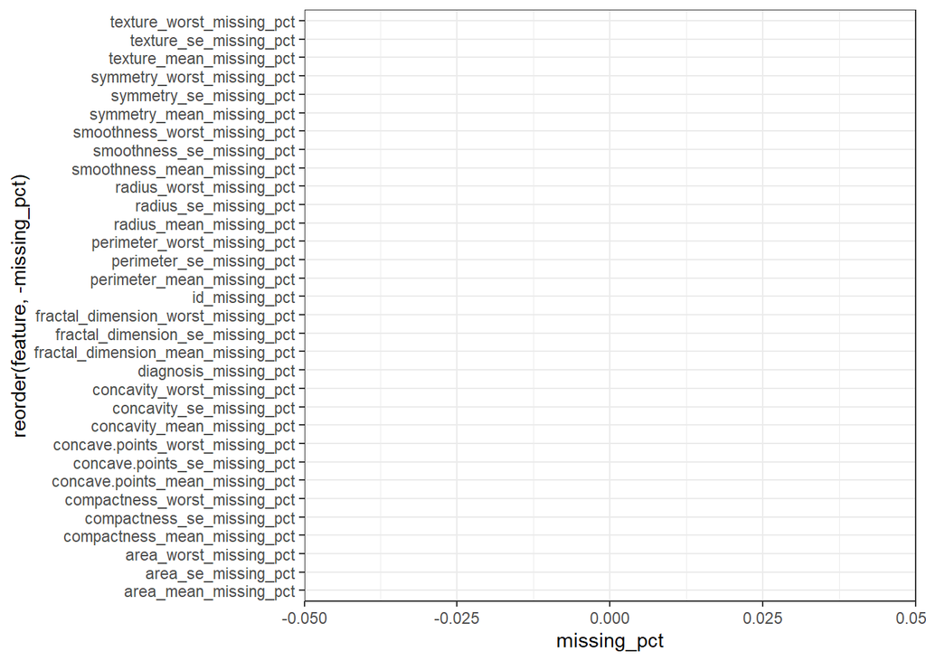

```r
# summarize_all() -> 각 열에 대해 주어진 함수를 적용하여 요약 통계를 계산
missing_values <- breast_cancer_data %>% summarize_all(list(missing_pct = ~sum(is.na(.))/n()))

# gather() -> "long" 형식으로 변환하여 시각화에 적합한 형태로 만듬
missing_values <- gather(missing_values, key="feature", value="missing_pct")

# ggplot 함수를 사용하여 막대 그래프를 생성
missing_values %>%
  ggplot(aes(x=reorder(feature, -missing_pct), y=missing_pct)) +
  geom_bar(stat="identity", fill="red") +
  coord_flip() +
  theme_bw()
```

- 누락된 데이터가 없어 패턴이 없음

[figure not shown]

```
##
##  Variables sorted by number of missings:
##  Variable Count
##               0
```

```r
# aggr 함수는 'VIM' 패키지에 속한 함수로서, 데이터셋의 결측값을 다양한 그래픽으로 요약하여 제공
## data: 시각화할 데이터프레임
## prop: 각 변수별 결측값 비율을 보여줄지 여부 (기본값: FALSE)
## combined: 결측값이 있는 행 또는 열을 표시하는 방법 (기본값: TRUE)
## numbers: 숫자를 사용하여 그래프를 그릴지 여부 (기본값: TRUE)
## sortVars: 변수들을 결측값의 비율에 따라 정렬할지 여부 (기본값: TRUE)
## sortCombs: 그래픽 표현을 정렬할지 여부 (기본값: TRUE)

aggr(data, prop = FALSE, combined = TRUE, numbers = TRUE, sortVars = TRUE, sortCombs = TRUE)
```

## Step 4: Target variable

```r
# about diagnosis variable

## 빈도표
table(breast_cancer_data$diagnosis)
```

```
##
##   B   M
## 357 212
```

```r
## 상대 빈도표
prop.table(table(breast_cancer_data$diagnosis))*100
```

```
##
##        B        M
## 62.74165 37.25835
```

- Target variable 는 문자형 변수이므로 팩터로 변환하는 것을 권장

```r
# 팩터로 변환
breast_cancer_data$diagnosis <- factor(breast_cancer_data$diagnosis, labels=c('B','M'))

# 상대 빈도표 재출력
prop.table(table(breast_cancer_data$diagnosis))*100
```

```
##
##        B        M
## 62.74165 37.25835
```

## Step 5: Descriptive analysis

- psych::는 R에서 패키지 함수를 지정할 때 사용되는 표기법 중 하나
- R에서 여러 패키지가 동일한 이름의 함수를 가질 수 있기 때문에 특정 패키지의 함수를 사용하려면 함수 이름 앞에 패키지이름::을 붙여서 명시적으로 지정

```r
# psych 패키지의 describeBy 함수 사용
# 데이터프레임의 3번째부터 32번째 열까지의 변수를 diagnosis 열을 기준으로 그룹화하여 각 그룹에 대한 요약 통계량을 생성
psych::describeBy(breast_cancer_data[3:32], group = breast_cancer_data$diagnosis)
```

```
##
##  Descriptive statistics by group
## group: B
##                         vars   n   mean     sd median trimmed    mad    min
## radius_mean                1 357  12.15   1.78  12.20   12.17   1.69   6.98
## texture_mean               2 357  17.91   4.00  17.39   17.52   3.47   9.71
## perimeter_mean             3 357  78.08  11.81  78.18   78.16  11.13  43.79
## area_mean                  4 357 462.79 134.29 458.40  459.40 127.06 143.50
## smoothness_mean            5 357   0.09   0.01   0.09    0.09   0.01   0.05
## compactness_mean           6 357   0.08   0.03   0.08    0.08   0.03   0.02
## concavity_mean             7 357   0.05   0.04   0.04    0.04   0.03   0.00
## concave.points_mean        8 357   0.03   0.02   0.02    0.02   0.01   0.00
## symmetry_mean              9 357   0.17   0.02   0.17    0.17   0.02   0.11
## fractal_dimension_mean    10 357   0.06   0.01   0.06    0.06   0.01   0.05
## radius_se                 11 357   0.28   0.11   0.26    0.27   0.10   0.11
## texture_se                12 357   1.22   0.59   1.11    1.16   0.51   0.36
## perimeter_se              13 357   2.00   0.77   1.85    1.91   0.68   0.76
## area_se                   14 357  21.14   8.84  19.63   20.15   7.13   6.80
## smoothness_se             15 357   0.01   0.00   0.01    0.01   0.00   0.00
## compactness_se            16 357   0.02   0.02   0.02    0.02   0.01   0.00
## concavity_se              17 357   0.03   0.03   0.02    0.02   0.01   0.00
## concave.points_se         18 357   0.01   0.01   0.01    0.01   0.00   0.00
## symmetry_se               19 357   0.02   0.01   0.02    0.02   0.01   0.01
## fractal_dimension_se      20 357   0.00   0.00   0.00    0.00   0.00   0.00
## radius_worst              21 357  13.38   1.98  13.35   13.39   2.02   7.93
## texture_worst             22 357  23.52   5.49  22.82   23.09   5.20  12.02
## perimeter_worst           23 357  87.01  13.53  86.92   86.97  13.54  50.41
## area_worst                24 357 558.90 163.60 547.40  553.64 162.05 185.20
## smoothness_worst          25 357   0.12   0.02   0.13    0.12   0.02   0.07
## compactness_worst         26 357   0.18   0.09   0.17    0.17   0.09   0.03
## concavity_worst           27 357   0.17   0.14   0.14    0.15   0.10   0.00
## concave.points_worst      28 357   0.07   0.04   0.07    0.07   0.03   0.00
## symmetry_worst            29 357   0.27   0.04   0.27    0.27   0.04   0.16
## fractal_dimension_worst   30 357   0.08   0.01   0.08    0.08   0.01   0.06
##                             max   range  skew kurtosis   se
## radius_mean               17.85   10.87 -0.08    -0.05 0.09
## texture_mean              33.81   24.10  0.97     1.16 0.21
## perimeter_mean           114.60   70.81 -0.06    -0.05 0.62
## area_mean                992.10  848.60  0.34     0.27 7.11
## smoothness_mean            0.16    0.11  0.66     1.79 0.00
```

[output cut: 74 more lines]

```
## compactness_se             0.14    0.13  1.83     5.40  0.00
## concavity_se               0.14    0.13  1.60     3.55  0.00
## concave.points_se          0.04    0.04  1.42     3.56  0.00
## symmetry_se                0.08    0.07  2.48     7.76  0.00
## fractal_dimension_se       0.01    0.01  1.65     3.80  0.00
## radius_worst              36.04   23.20  0.62     0.26  0.29
## texture_worst             49.54   32.87  0.53     1.06  0.37
## perimeter_worst          251.20  166.10  0.74     0.54  2.02
## area_worst              4254.00 3745.90  1.29     2.54 41.07
## smoothness_worst           0.22    0.13  0.43     0.73  0.00
## compactness_worst          1.06    1.01  1.09     1.60  0.01
## concavity_worst            1.17    1.15  0.90     1.31  0.01
## concave.points_worst       0.29    0.26 -0.09     0.08  0.00
## symmetry_worst             0.66    0.51  1.13     2.36  0.01
## fractal_dimension_worst    0.21    0.15  1.34     3.77  0.00
```

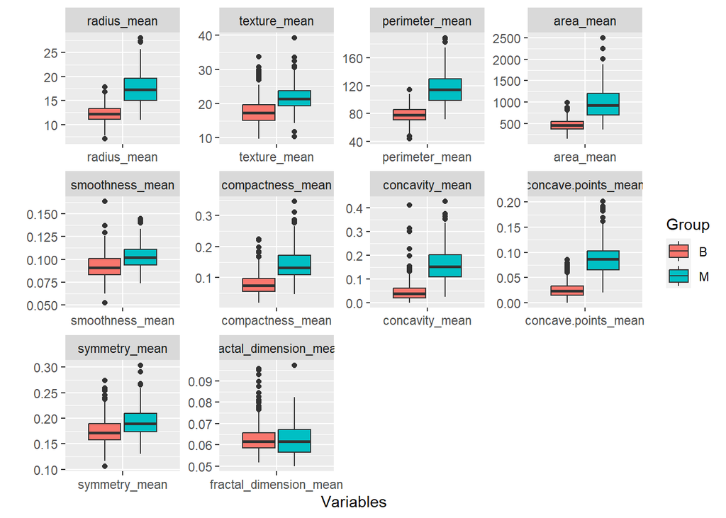

```r
#Mean
df.m <- melt(breast_cancer_data[,-c(1,13:32)], id.var = "diagnosis")
p <- ggplot(data = df.m, aes(x=variable, y=value)) +
  geom_boxplot(aes(fill=diagnosis)) + facet_wrap( ~ variable, scales="free")+ xlab("Variables") + ylab("")+ guides(fill=guide_legend(title="Group"))
p
```

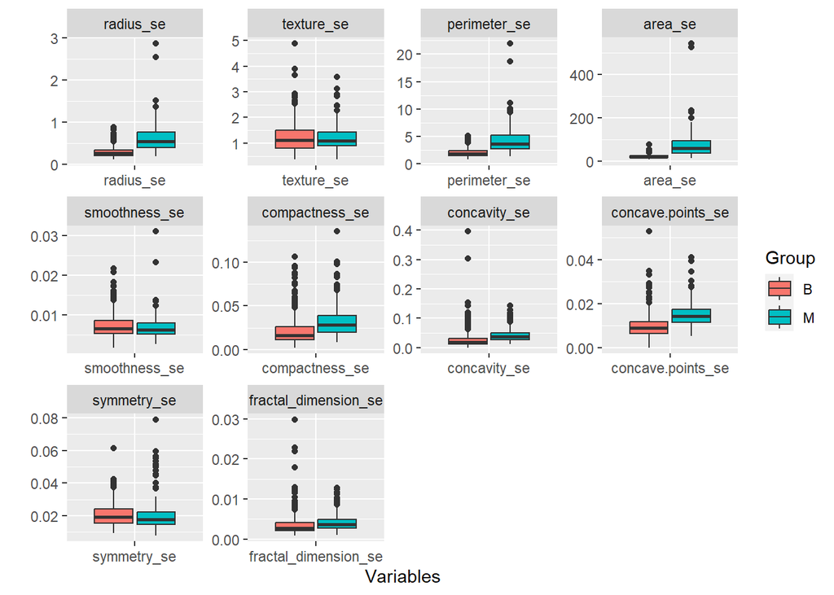

```r
#Se
df.m <- melt(breast_cancer_data[,-c(1,3:12,23:32)], id.var = "diagnosis")
p <- ggplot(data = df.m, aes(x=variable, y=value)) +
  geom_boxplot(aes(fill=diagnosis)) + facet_wrap( ~ variable, scales="free")+ xlab("Variables") + ylab("")+ guides(fill=guide_legend(title="Group"))
p
```

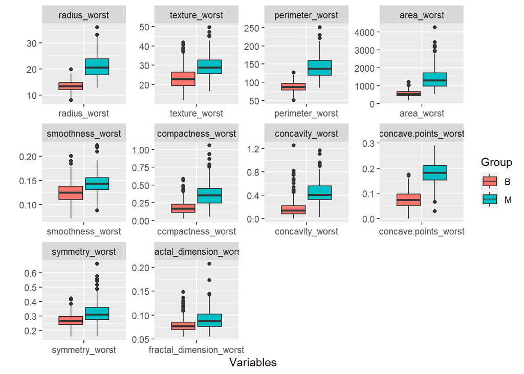

```r
#Worst
df.m <- melt(breast_cancer_data[,c(2,23:32)], id.var = "diagnosis")
p <- ggplot(data = df.m, aes(x=variable, y=value)) +
  geom_boxplot(aes(fill=diagnosis)) + facet_wrap( ~ variable, scales="free")+ xlab("Variables") + ylab("")+ guides(fill=guide_legend(title="Group"))
p
```

## Step 6: Correlations

- 아래 제시된 플롯은 변수 간의 패턴을 이해하기 위해 변수별로 패키지화 되어있음
- 이를 통해 일부 변수 사이에 매우 높은 상관관계가 있음을 알 수 있음

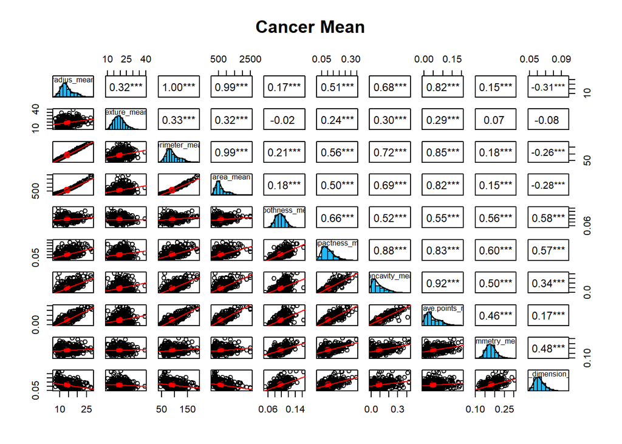

```r
pairs.panels(breast_cancer_data[,c(3:12)], method="pearson",
             hist.col = "#1fbbfa", density=TRUE, ellipses=TRUE, show.points = TRUE,
             pch=1, lm=TRUE, cex.cor=1, smoother=F, stars = T, main="Cancer Mean")
```

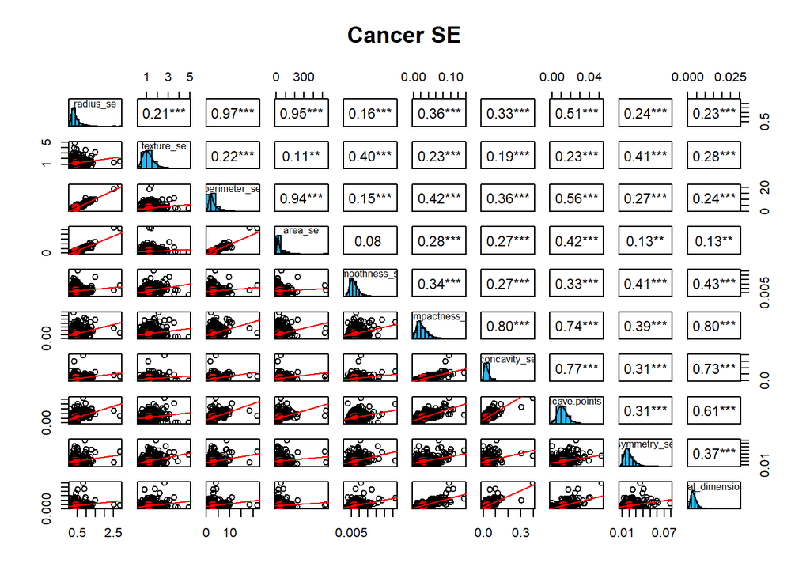

```r
pairs.panels(breast_cancer_data[,c(13:22)], method="pearson",
             hist.col = "#1fbbfa", density=TRUE, ellipses=TRUE, show.points = TRUE,
             pch=1, lm=TRUE, cex.cor=1, smoother=F, stars = T, main="Cancer SE")
```

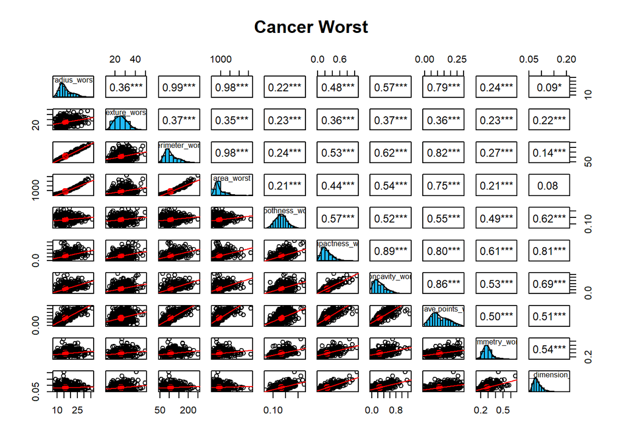

```r
pairs.panels(breast_cancer_data[,c(23:32)], method="pearson",
             hist.col = "#1fbbfa", density=TRUE, ellipses=TRUE, show.points = TRUE,
             pch=1, lm=TRUE, cex.cor=1, smoother=F, stars = T, main="Cancer Worst")
```

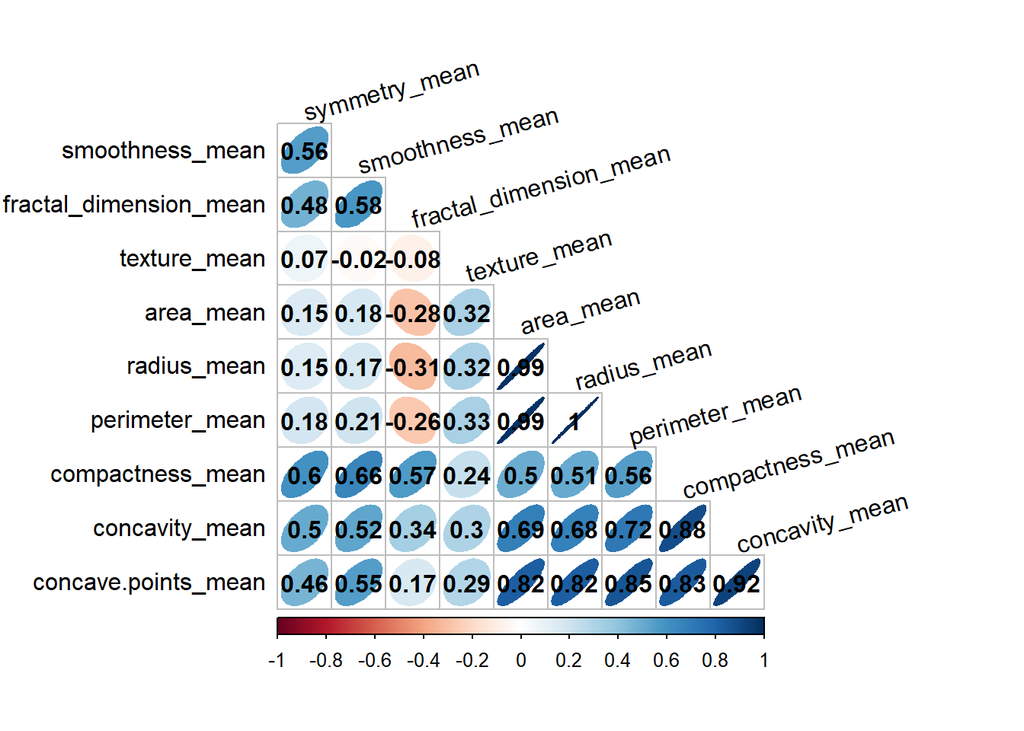

```r
w.corr<-cor(breast_cancer_data[,c(3:12)],method="pearson")
corrplot(w.corr, order='hclust', method='ellipse',addCoef.col = 'black',type='lower', number.cex = 1,tl.cex = 1, diag=F,tl.col = 'black',tl.srt=15)
```

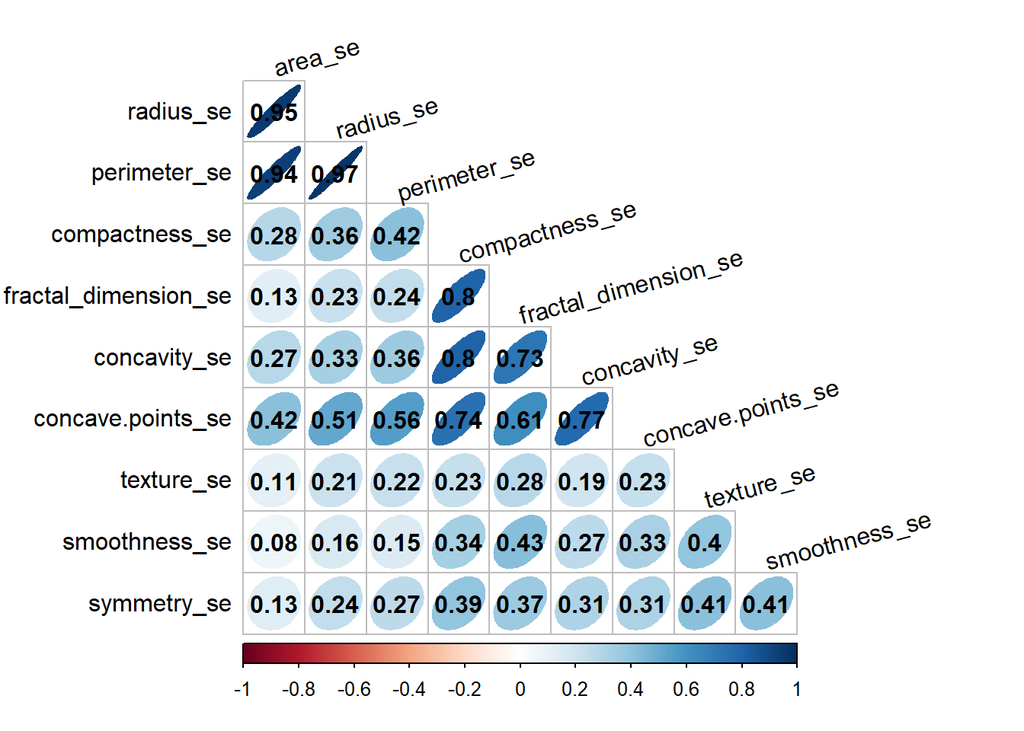

```r
w.corr<-cor(breast_cancer_data[,c(13:22)],method="pearson")
corrplot(w.corr, order='hclust', method='ellipse',addCoef.col = 'black',type='lower', number.cex = 1,tl.cex = 1, diag=F,tl.col = 'black',tl.srt=15)
```

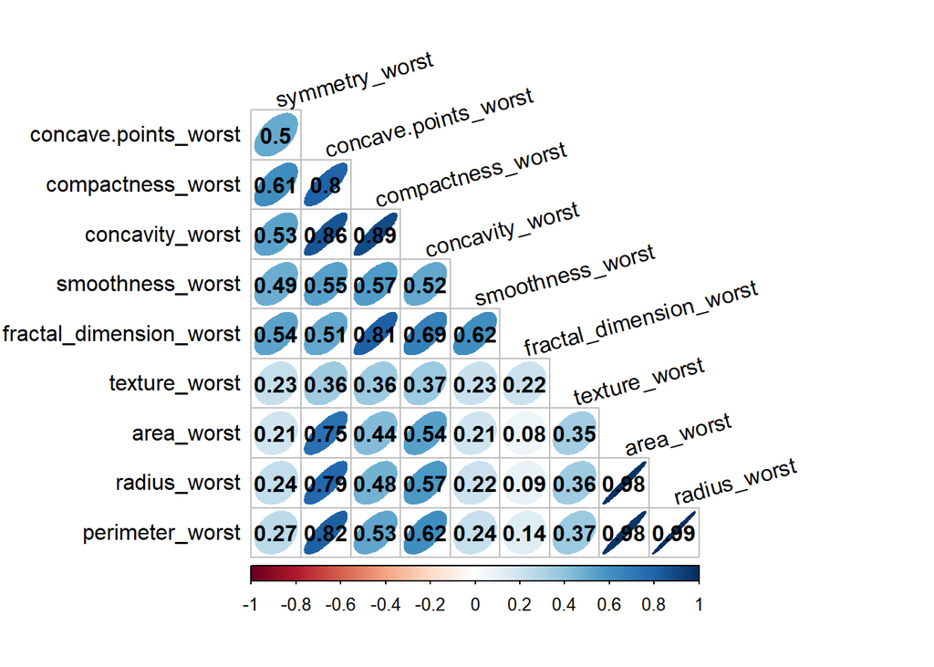

```r
w.corr<-cor(breast_cancer_data[,c(23:32)],method="pearson")
corrplot(w.corr, order='hclust', method='ellipse',addCoef.col = 'black',type='lower', number.cex = 1,tl.cex = 1, diag=F,tl.col = 'black',tl.srt=15)
```

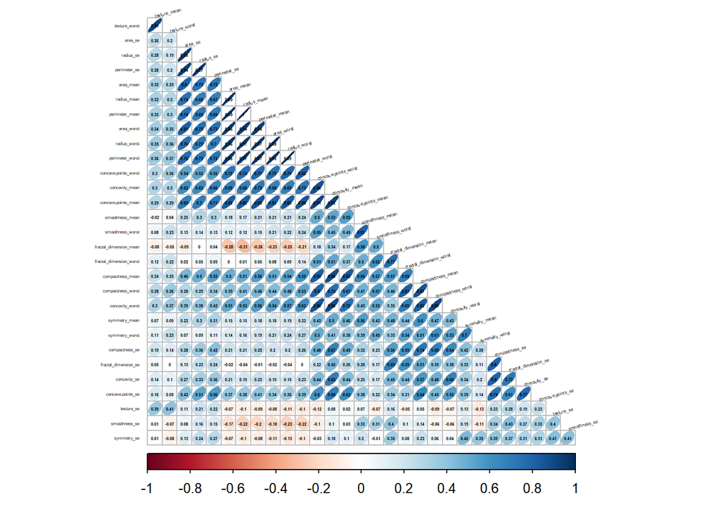

```r
w.corr<-cor(breast_cancer_data[,c(3:32)],method="pearson")
corrplot(w.corr, order='hclust', method='ellipse',addCoef.col = 'black',type='lower', number.cex = 0.25,tl.cex = 0.25, diag=F,tl.col = 'black',tl.srt=15)
```

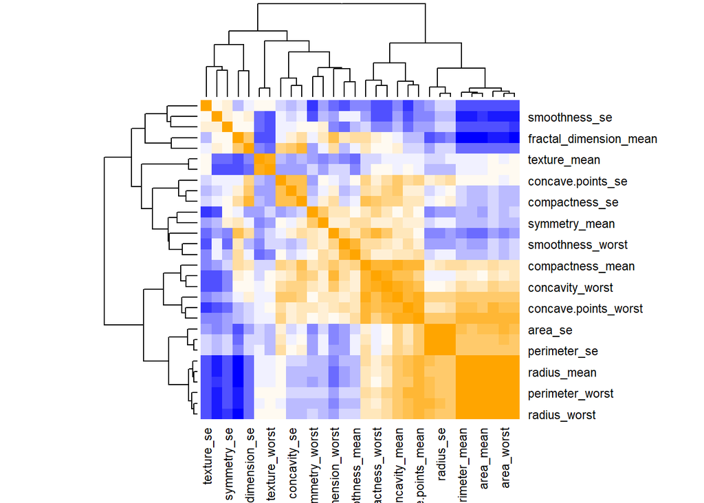

```r
# heatmap 그리기
col <- colorRampPalette(c('blue', 'white', 'orange'))(20)
heatmap(x=w.corr, col=col, symm=T)
```

## Step 7: Training and testing datasets

```r
dataset <- breast_cancer_data

head(dataset)
```

```
##         id diagnosis radius_mean texture_mean perimeter_mean area_mean
## 1   842302         M       17.99        10.38         122.80    1001.0
## 2   842517         M       20.57        17.77         132.90    1326.0
## 3 84300903         M       19.69        21.25         130.00    1203.0
## 4 84348301         M       11.42        20.38          77.58     386.1
## 5 84358402         M       20.29        14.34         135.10    1297.0
## 6   843786         M       12.45        15.70          82.57     477.1
##   smoothness_mean compactness_mean concavity_mean concave.points_mean
## 1         0.11840          0.27760         0.3001             0.14710
## 2         0.08474          0.07864         0.0869             0.07017
## 3         0.10960          0.15990         0.1974             0.12790
## 4         0.14250          0.28390         0.2414             0.10520
## 5         0.10030          0.13280         0.1980             0.10430
## 6         0.12780          0.17000         0.1578             0.08089
##   symmetry_mean fractal_dimension_mean radius_se texture_se perimeter_se
```

[output cut: 34 more lines]

- 데이터 세트는 training (70%)과 testing (30%)의 두 가지 데이터 세트로 나뉩니다.

```r
set.seed(123)
smp_size <- floor(0.70 * nrow(dataset))
train_ind <- sample(seq_len(nrow(dataset)), size = smp_size)

#  training (70%)
train <- dataset[train_ind, ]

# testing (30%)
test <- dataset[-train_ind, ]
```

- Let’s check the target variable.

```r
# train
prop.table(table(train$diagnosis))*100
```

```
##
##        B        M
## 65.07538 34.92462
```

```r
# test
prop.table(table(test$diagnosis))*100
```

```
##
##        B        M
## 57.30994 42.69006
```

## Step 8: machine learning

### ML 1: Quinlan’s C5.0

Training the model.

```r
names(train)
```

```
##  [1] "id"                      "diagnosis"
##  [3] "radius_mean"             "texture_mean"
##  [5] "perimeter_mean"          "area_mean"
##  [7] "smoothness_mean"         "compactness_mean"
##  [9] "concavity_mean"          "concave.points_mean"
## [11] "symmetry_mean"           "fractal_dimension_mean"
## [13] "radius_se"               "texture_se"
## [15] "perimeter_se"            "area_se"
## [17] "smoothness_se"           "compactness_se"
## [19] "concavity_se"            "concave.points_se"
## [21] "symmetry_se"             "fractal_dimension_se"
## [23] "radius_worst"            "texture_worst"
## [25] "perimeter_worst"         "area_worst"
## [27] "smoothness_worst"        "compactness_worst"
## [29] "concavity_worst"         "concave.points_worst"
## [31] "symmetry_worst"          "fractal_dimension_worst"
```

```r
learn_c50 <- C5.0(train[,-c(1,2)],train$diagnosis)
learn_c50
```

```
##
## Call:
## C5.0.default(x = train[, -c(1, 2)], y = train$diagnosis)
##
## Classification Tree
## Number of samples: 398
## Number of predictors: 30
##
## Tree size: 10
##
## Non-standard options: attempt to group attributes
```

Testing the model.

```r
pre_c50 <- predict(learn_c50, test[,-c(1,2)])
cm_c50 <- confusionMatrix(pre_c50, test$diagnosis)
cm_c50
```

```
## Confusion Matrix and Statistics
##
##           Reference
## Prediction  B  M
##          B 92  5
##          M  6 68
##
##                Accuracy : 0.9357
##                  95% CI : (0.8878, 0.9675)
##     No Information Rate : 0.5731
##     P-Value [Acc > NIR] : <2e-16
##
##                   Kappa : 0.8688
##
##  Mcnemar's Test P-Value : 1
##
##             Sensitivity : 0.9388
##             Specificity : 0.9315
##          Pos Pred Value : 0.9485
##          Neg Pred Value : 0.9189
##              Prevalence : 0.5731
##          Detection Rate : 0.5380
##    Detection Prevalence : 0.5673
##       Balanced Accuracy : 0.9351
##
##        'Positive' Class : B
##
```

### ML 2: Quinlan’s C5.0 tunned

```r
# 초기화
acc_test <- numeric()
accuracy1 <- NULL; accuracy2 <- NULL

# 1부터 50까지의 시도 횟수에 대해 반복
for(i in 1:50){
    # C5.0 모델 학습
    learn_imp_c50 <- C5.0(train[,-c(1,2)], train$diagnosis, trials = i)

    # 테스트 데이터에 대한 예측
    p_c50 <- predict(learn_imp_c50, test[,-c(1,2)])

    # 혼동 행렬 계산 및 정확도 저장
    accuracy1 <- confusionMatrix(p_c50, test$diagnosis)
    accuracy2[i] <- accuracy1$overall[1]
}

# 결과 데이터프레임 생성
acc <- data.frame(t = seq(1, 50), cnt = accuracy2)

# 최적의 시도 횟수 추출
opt_t <- subset(acc, cnt == max(cnt))[1,]
sub <- paste("Optimal number of trials is", opt_t$t, "(accuracy:", opt_t$cnt, ") in C5.0")

# Highcharter를 사용한 그래프 생성
hchart(acc, 'line', hcaes(t, cnt)) %>%
  hc_title(text = "Accuracy With Varying Trials (C5.0)") %>%
  hc_subtitle(text = sub) %>%
  hc_add_theme(hc_theme_google()) %>%
  hc_xAxis(title = list(text = "Number of Trials")) %>%
  hc_yAxis(title = list(text = "Accuracy"))
```

[interactive chart not shown]

```r
# 훈련 중 가장 높은 정확도를 보이는 epoch일때의 모델을 사용
# opt_t$t는 최적의 횟수로 설정된 변수
learn_imp_c50 <- C5.0(train[,-c(1,2)],train$diagnosis,trials=opt_t$t)
pre_imp_c50 <- predict(learn_imp_c50, test[,-c(1,2)])
cm_imp_c50 <- confusionMatrix(pre_imp_c50, test$diagnosis)
cm_imp_c50
```

```
## Confusion Matrix and Statistics
##
##           Reference
## Prediction  B  M
##          B 94  4
##          M  4 69
##
##                Accuracy : 0.9532
##                  95% CI : (0.9099, 0.9796)
##     No Information Rate : 0.5731
##     P-Value [Acc > NIR] : <2e-16
##
##                   Kappa : 0.9044
##
##  Mcnemar's Test P-Value : 1
##
##             Sensitivity : 0.9592
##             Specificity : 0.9452
##          Pos Pred Value : 0.9592
##          Neg Pred Value : 0.9452
##              Prevalence : 0.5731
##          Detection Rate : 0.5497
##    Detection Prevalence : 0.5731
##       Balanced Accuracy : 0.9522
##
##        'Positive' Class : B
##
```

### ML 3: Rpart (recursive partitioning and regression trees)

```r
learn_rp <- rpart(diagnosis~.,data=train[,-1],control=rpart.control(minsplit=2))
```

Testing the model.

```r
pre_rp <- predict(learn_rp, test[,-c(1,2)], type="class")
cm_rp  <- confusionMatrix(pre_rp, test$diagnosis)
cm_rp
```

```
## Confusion Matrix and Statistics
##
##           Reference
## Prediction  B  M
##          B 92  7
##          M  6 66
##
##                Accuracy : 0.924
##                  95% CI : (0.8735, 0.9589)
##     No Information Rate : 0.5731
##     P-Value [Acc > NIR] : <2e-16
##
##                   Kappa : 0.8444
##
##  Mcnemar's Test P-Value : 1
##
##             Sensitivity : 0.9388
##             Specificity : 0.9041
##          Pos Pred Value : 0.9293
##          Neg Pred Value : 0.9167
##              Prevalence : 0.5731
##          Detection Rate : 0.5380
##    Detection Prevalence : 0.5789
##       Balanced Accuracy : 0.9214
##
##        'Positive' Class : B
##
```

### ML 4: Prunned Rpart (recursive partitioning and regression trees)

Training the model.

```r
learn_pru <- prune(learn_rp, cp=learn_rp$cptable[which.min(learn_rp$cptable[,"xerror"]),"CP"])
```

Testing the model.

```r
pre_pru <- predict(learn_pru, test[,-c(1,2)], type="class")
cm_pru <-confusionMatrix(pre_pru, test$diagnosis)
cm_pru
```

```
## Confusion Matrix and Statistics
##
##           Reference
## Prediction  B  M
##          B 92  7
##          M  6 66
##
##                Accuracy : 0.924
##                  95% CI : (0.8735, 0.9589)
##     No Information Rate : 0.5731
##     P-Value [Acc > NIR] : <2e-16
##
##                   Kappa : 0.8444
##
##  Mcnemar's Test P-Value : 1
##
##             Sensitivity : 0.9388
##             Specificity : 0.9041
##          Pos Pred Value : 0.9293
##          Neg Pred Value : 0.9167
##              Prevalence : 0.5731
##          Detection Rate : 0.5380
##    Detection Prevalence : 0.5789
##       Balanced Accuracy : 0.9214
##
##        'Positive' Class : B
##
```

### ML 5: Naive Bayes

Training the model.

```r
learn_nb <- naiveBayes(train[,-c(1,2)], train$diagnosis)
```

Testing the model.

```r
pre_nb <- predict(learn_nb, test[,-c(1,2)])
cm_nb <- confusionMatrix(pre_nb, test$diagnosis)
cm_nb
```

```
## Confusion Matrix and Statistics
##
##           Reference
## Prediction  B  M
##          B 94  7
##          M  4 66
##
##                Accuracy : 0.9357
##                  95% CI : (0.8878, 0.9675)
##     No Information Rate : 0.5731
##     P-Value [Acc > NIR] : <2e-16
##
##                   Kappa : 0.8678
##
##  Mcnemar's Test P-Value : 0.5465
##
##             Sensitivity : 0.9592
##             Specificity : 0.9041
##          Pos Pred Value : 0.9307
##          Neg Pred Value : 0.9429
##              Prevalence : 0.5731
##          Detection Rate : 0.5497
##    Detection Prevalence : 0.5906
##       Balanced Accuracy : 0.9316
##
##        'Positive' Class : B
##
```

### ML 6: Logistic regression

Training the model.

```r
# trainControl 함수를 사용하여 교차 검증을 설정
fitControl <- trainControl(
  method = "cv",            # 10-fold 교차 검증 선택
  number = 10,               # 10-fold 설정
  savePredictions = TRUE     # 예측 결과 저장 설정
)

# train 함수를 사용하여 로지스틱 회귀 모델 학습
lreg <- train(
  diagnosis ~ .,             # 예측 변수는 diagnosis를 제외한 모든 변수
  data = train[,-1],          # 학습 데이터셋
  method = "glm",             # 로지스틱 회귀 모델 선택
  family = binomial(),        # 이항 분포 선택
  trControl = fitControl      # 교차 검증 설정 적용
)

# 학습된 모델의 변수 중요도 출력
varImp(lreg)
```

```
## glm variable importance
##
##   only 20 most important variables shown (out of 30)
##
##                        Overall
## compactness_mean       100.000
## area_worst              49.148
## texture_mean            42.139
## radius_mean             29.428
## perimeter_mean          27.183
## area_mean               26.347
## concave.points_worst    20.740
## compactness_se          18.103
## texture_se              14.855
## concavity_se            14.234
## fractal_dimension_mean  13.895
## compactness_worst       12.366
## smoothness_mean         12.336
## fractal_dimension_se    11.483
## radius_worst             8.600
## smoothness_se            7.781
## concave.points_se        7.276
## symmetry_worst           6.283
## symmetry_se              5.739
## symmetry_mean            4.455
```

Testing the model.

```r
lreg_pred<-predict(lreg,test[,-c(1,2)])
cm_logistic<-confusionMatrix(lreg_pred,test$diagnosis)
cm_logistic
```

```
## Confusion Matrix and Statistics
##
##           Reference
## Prediction  B  M
##          B 94  2
##          M  4 71
##
##                Accuracy : 0.9649
##                  95% CI : (0.9252, 0.987)
##     No Information Rate : 0.5731
##     P-Value [Acc > NIR] : <2e-16
##
##                   Kappa : 0.9285
##
##  Mcnemar's Test P-Value : 0.6831
##
##             Sensitivity : 0.9592
##             Specificity : 0.9726
##          Pos Pred Value : 0.9792
##          Neg Pred Value : 0.9467
##              Prevalence : 0.5731
##          Detection Rate : 0.5497
##    Detection Prevalence : 0.5614
##       Balanced Accuracy : 0.9659
##
##        'Positive' Class : B
##
```

### ML 7: Random Forest

Training the model.

```r
learn_ranger  <- train(diagnosis ~ ., data = train[,-1], method = "ranger")
learn_ranger
```

```
## Random Forest
##
## 398 samples
##  30 predictor
##   2 classes: 'B', 'M'
##
## No pre-processing
## Resampling: Bootstrapped (25 reps)
## Summary of sample sizes: 398, 398, 398, 398, 398, 398, ...
## Resampling results across tuning parameters:
##
##   mtry  splitrule   Accuracy   Kappa
##    2    gini        0.9560413  0.9010058
##    2    extratrees  0.9539226  0.8959805
##   16    gini        0.9470317  0.8821580
##   16    extratrees  0.9608528  0.9121873
##   30    gini        0.9418824  0.8707818
##   30    extratrees  0.9630772  0.9172766
##
## Tuning parameter 'min.node.size' was held constant at a value of 1
## Accuracy was used to select the optimal model using the largest value.
## The final values used for the model were mtry = 30, splitrule = extratrees
##  and min.node.size = 1.
```

Testing the model.

```r
pre_ranger <- predict(learn_ranger, test[,-c(1,2)])
cm_ranger <- confusionMatrix(pre_ranger, test$diagnosis)
cm_ranger
```

```
## Confusion Matrix and Statistics
##
##           Reference
## Prediction  B  M
##          B 95  4
##          M  3 69
##
##                Accuracy : 0.9591
##                  95% CI : (0.9175, 0.9834)
##     No Information Rate : 0.5731
##     P-Value [Acc > NIR] : <2e-16
##
##                   Kappa : 0.9162
##
##  Mcnemar's Test P-Value : 1
##
##             Sensitivity : 0.9694
##             Specificity : 0.9452
##          Pos Pred Value : 0.9596
##          Neg Pred Value : 0.9583
##              Prevalence : 0.5731
##          Detection Rate : 0.5556
##    Detection Prevalence : 0.5789
##       Balanced Accuracy : 0.9573
##
##        'Positive' Class : B
##
```

### ML 8: Classification tree

Training the model.

```r
learn_ct <- ctree(diagnosis~., data=train[,-1], controls=ctree_control(maxdepth=2))
```

Testing the model.

```r
pre_ct   <- predict(learn_ct, test[,-c(1,2)])
cm_ct    <- confusionMatrix(pre_ct, test$diagnosis)
cm_ct
```

```
## Confusion Matrix and Statistics
##
##           Reference
## Prediction  B  M
##          B 93 11
##          M  5 62
##
##                Accuracy : 0.9064
##                  95% CI : (0.8525, 0.9456)
##     No Information Rate : 0.5731
##     P-Value [Acc > NIR] : <2e-16
##
##                   Kappa : 0.8068
##
##  Mcnemar's Test P-Value : 0.2113
##
##             Sensitivity : 0.9490
##             Specificity : 0.8493
##          Pos Pred Value : 0.8942
##          Neg Pred Value : 0.9254
##              Prevalence : 0.5731
##          Detection Rate : 0.5439
##    Detection Prevalence : 0.6082
##       Balanced Accuracy : 0.8991
##
##        'Positive' Class : B
##
```

### ML 9: K-nn

Training the model.

- repeatedcv : repeated cross-validation / repeated 교차 검증
- 즉 교차검증을 여러 번 반복하는 것을 의미
- tuneLength = 20 : 모델 파라미터의 후보 값들 중에서 20개를 테스트

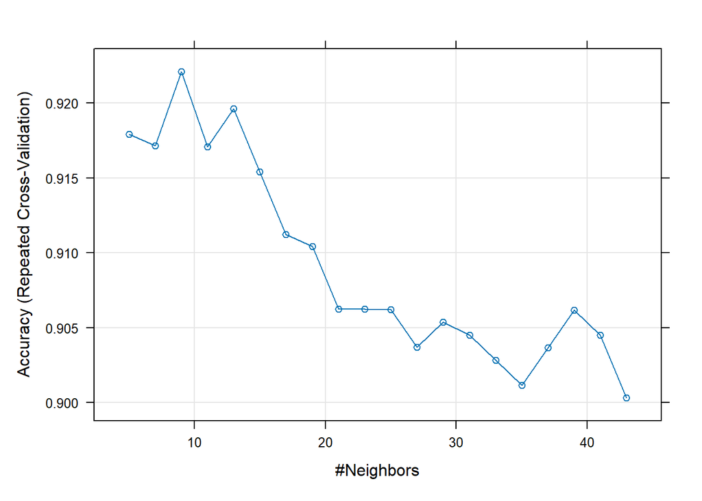

```r
# trainControl 함수를 사용하여 교차 검증을 설정
control <- trainControl(method='repeatedcv',
                        number=10,
                        repeats=3)

# train 함수를 사용하여 k-nn 모델 학습
knnFit <- train(diagnosis ~ .,
                data = train[,-1],      # 학습 데이터셋
                method = "knn",         # k-nn 모델 선택
                trControl = control,    # 교차 검증 설정 적용
                tuneLength = 20)        # 모델 파라미터 튜닝 범위의 길이

# 학습된 모델의 성능 시각화
plot(knnFit)
```

Testing the model.

```r
knnPredict <- predict(knnFit,newdata = test )
cm_knn<-confusionMatrix(knnPredict, test$diagnosis )
cm_knn
```

```
## Confusion Matrix and Statistics
##
##           Reference
## Prediction  B  M
##          B 96  5
##          M  2 68
##
##                Accuracy : 0.9591
##                  95% CI : (0.9175, 0.9834)
##     No Information Rate : 0.5731
##     P-Value [Acc > NIR] : <2e-16
##
##                   Kappa : 0.9159
##
##  Mcnemar's Test P-Value : 0.4497
##
##             Sensitivity : 0.9796
##             Specificity : 0.9315
##          Pos Pred Value : 0.9505
##          Neg Pred Value : 0.9714
##              Prevalence : 0.5731
##          Detection Rate : 0.5614
##    Detection Prevalence : 0.5906
##       Balanced Accuracy : 0.9555
##
##        'Positive' Class : B
##
```

### ML 10: K-means

Training the model.

```r
predict.kmeans <- function(newdata, object){
    # 클러스터 중심 좌표 가져오기
    centers <- object$centers

    # 중심 좌표의 개수
    n_centers <- nrow(centers)

    # 새로운 데이터와 클러스터 중심 간의 거리 계산
    dist_mat <- as.matrix(dist(rbind(centers, newdata)))

    # 거리 행렬에서 새로운 데이터와의 거리만 추출
    dist_mat <- dist_mat[-seq(n_centers), seq(n_centers)]

    # 거리가 가장 작은 클러스터 선택
    max.col(-dist_mat)
}
```

```r
learn_kmeans <- kmeans(train[,-c(1,2)], centers=2)
```

Testing the model.

```r
pre_kmeans <- predict.kmeans(test[,-c(1,2)],learn_kmeans)
pre_kmeans <- factor(ifelse(pre_kmeans == 1,"B","M"))
cm_kmeans <- confusionMatrix(pre_kmeans, test$diagnosis)
cm_kmeans
```

```
## Confusion Matrix and Statistics
##
##           Reference
## Prediction  B  M
##          B 97 25
##          M  1 48
##
##                Accuracy : 0.848
##                  95% CI : (0.7852, 0.8982)
##     No Information Rate : 0.5731
##     P-Value [Acc > NIR] : 1.074e-14
##
##                   Kappa : 0.6757
##
##  Mcnemar's Test P-Value : 6.462e-06
##
##             Sensitivity : 0.9898
##             Specificity : 0.6575
##          Pos Pred Value : 0.7951
##          Neg Pred Value : 0.9796
##              Prevalence : 0.5731
##          Detection Rate : 0.5673
##    Detection Prevalence : 0.7135
##       Balanced Accuracy : 0.8237
##
##        'Positive' Class : B
##
```

### ML 11: Gradient boosting machines(GBM)

Training the model.

```r
# GBM 모델 생성
test_gbm <- gbm(
  diagnosis ~ .,
  data = train[,-1],
  distribution = "gaussian",
  n.trees = 10000,
  shrinkage = 0.01,
  interaction.depth = 4,
  bag.fraction = 0.5,
  train.fraction = 0.5,
  n.minobsinnode = 10,
  cv.folds = 3,
  keep.data = TRUE,
  verbose = FALSE,
  n.cores = 1
)
```

```
## CV: 1
## CV: 2
## CV: 3
```

```r
# 최적의 트리 개수 찾기
best.iter <- gbm.perf(test_gbm, method="cv",plot.it=FALSE)

# GBM 모델 훈련
fitControl = trainControl(
  method = "cv",
  number = 5,
  returnResamp = "all"
)
learn_gbm = train(
  diagnosis ~ .,
  data = train[,-1],
  method = "gbm",
  distribution = "bernoulli",
  trControl = fitControl,
  verbose = FALSE,
  tuneGrid = data.frame(
    .n.trees = best.iter,
    .shrinkage = 0.01,
    .interaction.depth = 1,
    .n.minobsinnode = 1
  )
)
```

- “CV”는 Cross Validation(교차 검증)
- “CV: 1”, “CV: 2”, “CV: 3”은 세 번의 교차 검증이 진행됨을 나타냄

Testing the model.

```r
pre_gbm <- predict(learn_gbm, test[,-c(1,2)])
cm_gbm <- confusionMatrix(pre_gbm, test$diagnosis)
cm_gbm
```

```
## Confusion Matrix and Statistics
##
##           Reference
## Prediction  B  M
##          B 95  5
##          M  3 68
##
##                Accuracy : 0.9532
##                  95% CI : (0.9099, 0.9796)
##     No Information Rate : 0.5731
##     P-Value [Acc > NIR] : <2e-16
##
##                   Kappa : 0.9041
##
##  Mcnemar's Test P-Value : 0.7237
##
##             Sensitivity : 0.9694
##             Specificity : 0.9315
##          Pos Pred Value : 0.9500
##          Neg Pred Value : 0.9577
##              Prevalence : 0.5731
##          Detection Rate : 0.5556
##    Detection Prevalence : 0.5848
##       Balanced Accuracy : 0.9504
##
##        'Positive' Class : B
##
```

### ML 12: Adaboost

Training the model.

```r
control <- rpart.control(cp = -1, maxdepth = 14,maxcompete = 1,xval = 0)
learn_ada <- ada(diagnosis~., data = train[,-1], test.x = train[,-c(1,2)], test.y = train$diagnosis, type = "gentle", control = control, iter = 70)
```

Testing the model.

```r
pre_ada <- predict(learn_ada, test[,-c(1,2)])
cm_ada <- confusionMatrix(pre_ada, test$diagnosis)
cm_ada
```

```
## Confusion Matrix and Statistics
##
##           Reference
## Prediction  B  M
##          B 96  6
##          M  2 67
##
##                Accuracy : 0.9532
##                  95% CI : (0.9099, 0.9796)
##     No Information Rate : 0.5731
##     P-Value [Acc > NIR] : <2e-16
##
##                   Kappa : 0.9037
##
##  Mcnemar's Test P-Value : 0.2888
##
##             Sensitivity : 0.9796
##             Specificity : 0.9178
##          Pos Pred Value : 0.9412
##          Neg Pred Value : 0.9710
##              Prevalence : 0.5731
##          Detection Rate : 0.5614
##    Detection Prevalence : 0.5965
##       Balanced Accuracy : 0.9487
##
##        'Positive' Class : B
##
```

### ML 13: Support vector machines(SVM)

Training the model.

```r
# SVM 모델 학습
learn_svm <- svm(diagnosis ~ ., data = train[,-1])
```

Testing the model.

```r
# SVM 모델로 테스트 데이터 예측
pre_svm <- predict(learn_svm, test[,-c(1,2)])

# Confusion Matrix 계산
cm_svm <- confusionMatrix(pre_svm, test$diagnosis)

# Confusion Matrix 출력
cm_svm
```

```
## Confusion Matrix and Statistics
##
##           Reference
## Prediction  B  M
##          B 98  5
##          M  0 68
##
##                Accuracy : 0.9708
##                  95% CI : (0.9331, 0.9904)
##     No Information Rate : 0.5731
##     P-Value [Acc > NIR] : < 2e-16
##
##                   Kappa : 0.9397
##
##  Mcnemar's Test P-Value : 0.07364
##
##             Sensitivity : 1.0000
##             Specificity : 0.9315
##          Pos Pred Value : 0.9515
##          Neg Pred Value : 1.0000
##              Prevalence : 0.5731
##          Detection Rate : 0.5731
##    Detection Prevalence : 0.6023
##       Balanced Accuracy : 0.9658
##
##        'Positive' Class : B
##
```

### ML 14: Tunned Support vector machines

Training the model.

```r
# Hyperparameter 그리드 생성
gamma <- seq(0, 0.1, 0.005)
cost <- 2^(0:5)
parms <- expand.grid(cost = cost, gamma = gamma)

# 결과 저장 변수 초기화
acc_test <- numeric()
accuracy1 <- NULL
accuracy2 <- NULL

# 각각의 하이퍼파라미터에 대해 SVM 모델 학습 및 평가
for (i in 1:NROW(parms)) {
  learn_svm <- svm(diagnosis ~ ., data = train[,-1], gamma = parms$gamma[i], cost = parms$cost[i])
  pre_svm <- predict(learn_svm, test[,-c(1,2)])
  accuracy1 <- confusionMatrix(pre_svm, test$diagnosis)
  accuracy2[i] <- accuracy1$overall[1]
}

# 결과 데이터프레임 생성
acc <- data.frame(p = seq(1, NROW(parms)), cnt = accuracy2)

# 최적의 하이퍼파라미터 및 정확도 확인
opt_p <- subset(acc, cnt == max(cnt))[1,]
sub <- paste("Optimal number of parameters is", opt_p$p, "(accuracy:", opt_p$cnt, ") in SVM")

# 그래프 그리기
hchart(acc, 'line', hcaes(p, cnt)) %>%
  hc_title(text = "Accuracy With Varying Parameters (SVM)") %>%
  hc_subtitle(text = sub) %>%
  hc_add_theme(hc_theme_google()) %>%
  hc_xAxis(title = list(text = "Number of Parameters")) %>%
  hc_yAxis(title = list(text = "Accuracy"))
```

[interactive chart not shown]

```r
# Improved SVM 모델 학습
learn_imp_svm <- svm(diagnosis~., data=train[,-1], cost=parms$cost[opt_p$p], gamma=parms$gamma[opt_p$p])
```

Testing the model.

```r
# Improved SVM 모델을 사용하여 테스트 데이터에 대한 예측 수행
pre_imp_svm <- predict(learn_imp_svm, test[,-c(1,2)])

# Confusion Matrix 계산
cm_imp_svm <- confusionMatrix(pre_imp_svm, test$diagnosis)
cm_imp_svm
```

```
## Confusion Matrix and Statistics
##
##           Reference
## Prediction  B  M
##          B 98  3
##          M  0 70
##
##                Accuracy : 0.9825
##                  95% CI : (0.9496, 0.9964)
##     No Information Rate : 0.5731
##     P-Value [Acc > NIR] : <2e-16
##
##                   Kappa : 0.964
##
##  Mcnemar's Test P-Value : 0.2482
##
##             Sensitivity : 1.0000
##             Specificity : 0.9589
##          Pos Pred Value : 0.9703
##          Neg Pred Value : 1.0000
##              Prevalence : 0.5731
##          Detection Rate : 0.5731
##    Detection Prevalence : 0.5906
##       Balanced Accuracy : 0.9795
##
##        'Positive' Class : B
##
```

### ML 15: Random Forest: ranger

- 랜덤 포레스트 모델의 ranger 알고리즘을 사용
- 일반 랜덤 포레스트보다 빠르다고 함(정확한 내용은 모르겠음)

Training the model.

```r
# Random Forest 모델에 사용될 매개변수 그리드 정의
tgrid <- expand.grid(
  .mtry = 2:4,
  .splitrule = "gini",
  .min.node.size = c(10, 20)
)

# ranger를 사용한 Random Forest 모델 생성
ranger_caret <- train(
  diagnosis ~ .,                  # 종속 변수 및 독립 변수 설정
  data = train[, -1],             # 훈련 데이터 설정
  method = "ranger",              # 사용할 머신 러닝 알고리즘
  trControl = fitControl,         # 교차 검증 및 기타 제어 매개변수 설정
  tuneGrid = tgrid,               # 매개변수 그리드 설정
  num.trees = 100,                # 나무의 개수 설정
  importance = "permutation"      # 변수 중요도 계산 방법 설정
)

# 변수 중요도 계산
varImp(ranger_caret)
```

```
## ranger variable importance
##
##   only 20 most important variables shown (out of 30)
##
##                         Overall
## radius_worst            100.000
## perimeter_worst          95.703
## concave.points_worst     79.880
## concave.points_mean      75.921
## area_worst               65.306
## area_mean                54.996
## area_se                  44.697
## perimeter_mean           41.811
## concavity_mean           40.079
## concavity_worst          32.024
## radius_mean              23.781
## texture_worst            17.783
## radius_se                16.699
## concavity_se             13.195
## perimeter_se             11.545
## compactness_worst        11.522
## texture_mean             10.402
## smoothness_worst         10.399
## fractal_dimension_worst   5.898
## symmetry_worst            4.949
```

Testing the model.

```r
# Random Forest 모델을 사용하여 테스트 데이터에 대한 예측 수행
Rangercaret_pred <- predict(ranger_caret, test[,-c(1,2)])

# Confusion Matrix 계산
cm_Ranger <- confusionMatrix(Rangercaret_pred, test$diagnosis)
cm_Ranger
```

```
## Confusion Matrix and Statistics
##
##           Reference
## Prediction  B  M
##          B 95  4
##          M  3 69
##
##                Accuracy : 0.9591
##                  95% CI : (0.9175, 0.9834)
##     No Information Rate : 0.5731
##     P-Value [Acc > NIR] : <2e-16
##
##                   Kappa : 0.9162
##
##  Mcnemar's Test P-Value : 1
##
##             Sensitivity : 0.9694
##             Specificity : 0.9452
##          Pos Pred Value : 0.9596
##          Neg Pred Value : 0.9583
##              Prevalence : 0.5731
##          Detection Rate : 0.5556
##    Detection Prevalence : 0.5789
##       Balanced Accuracy : 0.9573
##
##        'Positive' Class : B
##
```

### ML 16: Random Forest: caret+RF

Training the model.

```r
# 10-fold 교차 검증을 3번 반복하는 제어 매개변수 설정
control <- trainControl(method='repeatedcv',
                        number=10,
                        repeats=3)

# 모델 평가 지표로 사용할 Accuracy 설정
metric <- "Accuracy"

# 난수 생성기 시드 설정
set.seed(123)

# 랜덤 포레스트 모델의 mtry 매개변수 튜닝을 위한 매개변수 그리드 설정
mtry <- sqrt(ncol(train))
tunegrid <- expand.grid(.mtry=mtry)

# caret 패키지를 사용하여 랜덤 포레스트 모델 훈련
rf_caret <- train(diagnosis~.,data=train[,-1],
                      method='rf',
                      metric='Accuracy',
                      tuneGrid=tunegrid,
                      trControl=control)

# 변수 중요도 계산 및 출력
varImp(rf_caret)
```

```
## rf variable importance
##
##   only 20 most important variables shown (out of 30)
##
##                         Overall
## concave.points_worst    100.000
## perimeter_worst          90.099
## radius_worst             74.911
## concave.points_mean      70.527
## area_worst               56.590
## perimeter_mean           31.699
## concavity_mean           28.384
## radius_mean              25.421
## area_mean                18.469
## concavity_worst          15.408
## area_se                   8.774
## texture_worst             8.452
## compactness_worst         6.444
## smoothness_worst          5.960
## texture_mean              5.779
## symmetry_worst            5.579
## perimeter_se              4.676
## radius_se                 3.880
## compactness_mean          2.915
## fractal_dimension_worst   2.741
```

Testing the model.

```r
RFcaret_pred<-predict(rf_caret,test[,-c(1,2)])
cm_rf<-confusionMatrix(RFcaret_pred,test$diagnosis)
cm_rf
```

```
## Confusion Matrix and Statistics
##
##           Reference
## Prediction  B  M
##          B 94  4
##          M  4 69
##
##                Accuracy : 0.9532
##                  95% CI : (0.9099, 0.9796)
##     No Information Rate : 0.5731
##     P-Value [Acc > NIR] : <2e-16
##
##                   Kappa : 0.9044
##
##  Mcnemar's Test P-Value : 1
##
##             Sensitivity : 0.9592
##             Specificity : 0.9452
##          Pos Pred Value : 0.9592
##          Neg Pred Value : 0.9452
##              Prevalence : 0.5731
##          Detection Rate : 0.5497
##    Detection Prevalence : 0.5731
##       Balanced Accuracy : 0.9522
##
##        'Positive' Class : B
##
```

## Step 9: The best model

이 커널에서는 여러 분류 ML 절차가 적용됨

##### Logistic Regression (로지스틱 회귀)

- **설명:** 로지스틱 회귀는 종속 변수가 이항인 경우 사용되는 통계 기법으로, 주로 이진 분류 문제에 적용됩니다. 확률 모델을 사용하여 각 클래스에 속할 확률을 예측합니다.
- **의미:** 종속 변수가 두 가지 범주 중 하나에 속하는 경우에 적합하며, 이를 통해 각 독립 변수의 영향을 평가할 수 있습니다.

##### Decision Tree (의사결정나무)

C5.0 및 improved C5.0

- **설명:** C5.0는 의사결정나무 알고리즘의 한 유형으로, 정보 이득을 최대화하여 데이터를 분할합니다. 개선된 C5.0는 C5.0의 성능을 향상시킨 버전입니다.
- **사용된 기법:** 정보 이득을 최대화하여 데이터를 잘게 나누어 각 분기에서의 예측 정확도를 높입니다.

##### Rpart와 Rpart pruned

- **설명:** Rpart는 의사결정나무 알고리즘으로, 나무를 성장시키고 가지치기를 통해 모델을 생성합니다. Pruned 옵션은 나무를 가지치기하여 과적합을 방지합니다.
- **사용된 기법:** 나무를 성장시키고, 필요에 따라 가지치기를 수행하여 모델을 생성합니다.

##### Naive Bayes (나이브 베이즈)

- **설명:** 나이브 베이즈는 베이즈 이론을 기반으로 하며, 각 독립 변수가 종속 변수에 미치는 영향을 독립적이라 가정합니다. 이는 계산의 단순성을 가져옵니다.
- **사용된 기법:** 독립 변수들 간의 조건부 독립 가정을 통해 베이즈 이론을 적용하여 클래스 확률을 계산합니다.

##### Random Forest (랜덤 포레스트)

a. ranger

- **설명:** Ranger는 랜덤 포레스트 모델의 한 구현체로, 여러 의사결정나무를 생성하고 각 나무의 예측을 결합하여 정확한 예측을 수행합니다.
- **사용된 기법:** 여러 의사결정나무를 병렬로 생성하고 예측을 결합하여 모델의 정확도를 향상시킵니다.

b. caret+ranger, caret+random forest

- **설명:** Caret 패키지를 활용하여 Ranger 및 Random Forest 모델을 훈련하고 최적의 매개변수를 찾아 모델의 정확도를 향상시킵니다.

##### K-nearest Neighbors (K-NN)

- **설명:** K-NN은 새로운 데이터 포인트와 가장 가까운 k개의 이웃을 찾아 다수결 투표를 통해 예측하는 알고리즘입니다.
- **사용된 기법:** 거리 측정 방법을 사용하여 가장 가까운 이웃을 찾아 예측합니다.

##### Classification Tree (분류 트리)

- **설명:** 분류 트리는 의사결정나무와 유사하지만 이진 분할을 사용하여 클래스를 예측하는 모델입니다.
- **사용된 기법:** 정보 이득이나 지니 불순도를 최소화하여 데이터를 분할하고 예측합니다.

##### Gradient Boosting Machine (GBM)

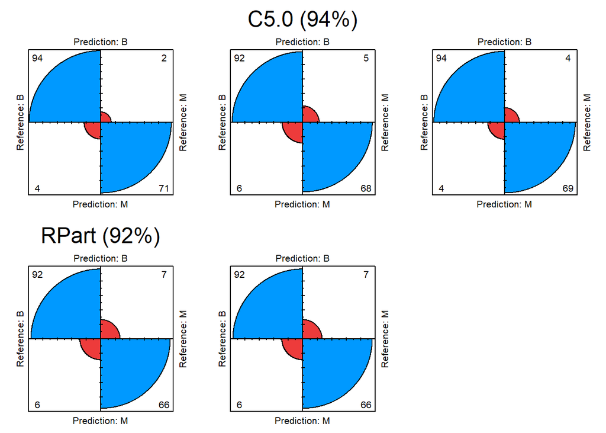

```r
# 색상 벡터 설정
col <- c("#ed3b3b", "#0099ff")

# Logistic, C5.0, Tuned C5.0, RPart, Prune 시각화
par(mfrow=c(2,3))
fourfoldplot(cm_logistic$table, color = col, conf.level = 0, margin = 1, main=paste("로지스틱 (", round(cm_ranger$overall[1]*100), "%)", sep=""))
fourfoldplot(cm_c50$table, color = col, conf.level = 0, margin = 1, main=paste("C5.0 (", round(cm_c50$overall[1]*100), "%)", sep=""))
fourfoldplot(cm_imp_c50$table, color = col, conf.level = 0, margin = 1, main=paste("튜닝된 C5.0 (", round(cm_imp_c50$overall[1]*100), "%)", sep=""))
fourfoldplot(cm_rp$table, color = col, conf.level = 0, margin = 1, main=paste("RPart (", round(cm_rp$overall[1]*100), "%)", sep=""))
fourfoldplot(cm_pru$table, color = col, conf.level = 0, margin = 1, main=paste("가지치기 (", round(cm_pru$overall[1]*100), "%)", sep=""))

# CTree, NaiveBayes, K-nn, GBM, AdaBoost 시각화
par(mfrow=c(2,3))
```

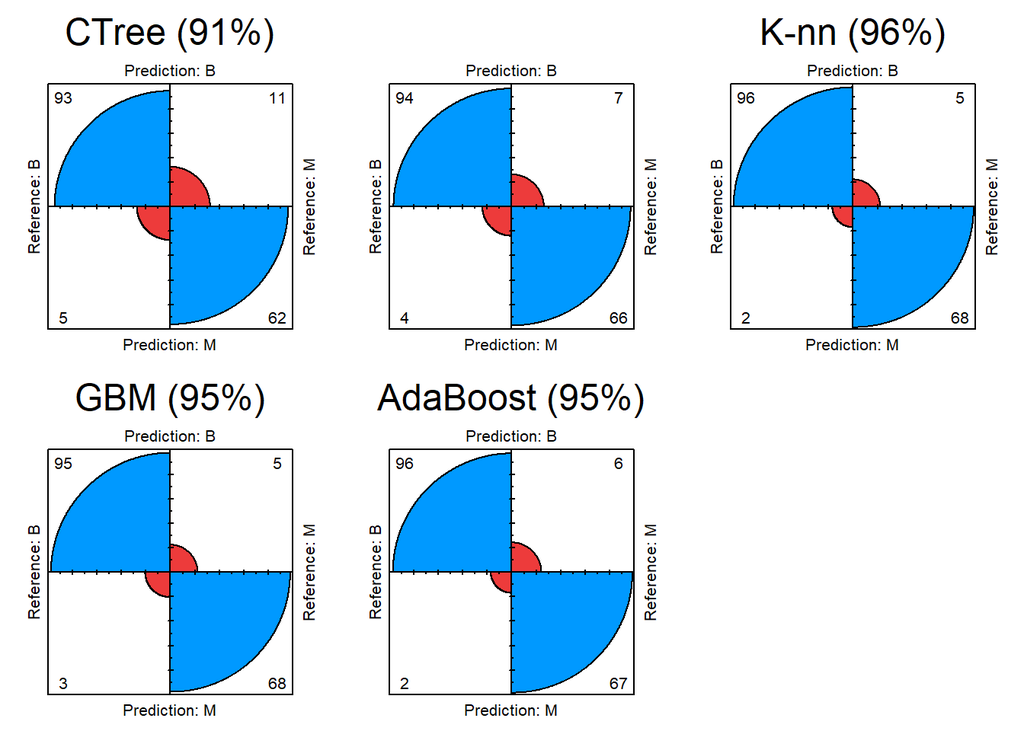

```r
fourfoldplot(cm_ct$table, color = col, conf.level = 0, margin = 1, main=paste("CTree (", round(cm_ct$overall[1]*100), "%)", sep=""))
fourfoldplot(cm_nb$table, color = col, conf.level = 0, margin = 1, main=paste("나이브 베이즈 (", round(cm_nb$overall[1]*100), "%)", sep=""))
fourfoldplot(cm_knn$table, color = col, conf.level = 0, margin = 1, main=paste("K-nn (", round(cm_ranger$overall[1]*100), "%)", sep=""))
fourfoldplot(cm_gbm$table, color = col, conf.level = 0, margin = 1, main=paste("GBM (", round(cm_gbm$overall[1]*100), "%)", sep=""))
fourfoldplot(cm_ada$table, color = col, conf.level = 0, margin = 1, main=paste("AdaBoost (", round(cm_ada$overall[1]*100), "%)", sep=""))

# SVM, Tuned SVM, RF, RF caret/ranger, RF caret/rf 시각화
par(mfrow=c(2,3))
```

[figure not shown]

```r
fourfoldplot(cm_svm$table, color = col, conf.level = 0, margin = 1, main=paste("SVM (", round(cm_svm$overall[1]*100), "%)", sep=""))
fourfoldplot(cm_imp_svm$table, color = col, conf.level = 0, margin = 1, main=paste("튜닝된 SVM (", round(cm_imp_svm$overall[1]*100), "%)", sep=""))
fourfoldplot(cm_ranger$table, color = col, conf.level = 0, margin = 1, main=paste("RF (", round(cm_ranger$overall[1]*100), "%)", sep=""))
fourfoldplot(cm_Ranger$table, color = col, conf.level = 0, margin = 1, main=paste("RF caret/ranger (", round(cm_ranger$overall[1]*100), "%)", sep=""))
fourfoldplot(cm_rf$table, color = col, conf.level = 0, margin = 1, main=paste("RF caret/rf (", round(cm_ranger$overall[1]*100), "%)", sep=""))
```

Which model is better?

```r
# 각 모델의 정확도 저장
opt_predict <- c(
  cm_logistic$overall[1],
  cm_ranger$overall[1],
  cm_Ranger$overall[1],
  cm_rf$overall[1],
  cm_c50$overall[1],
  cm_imp_c50$overall[1],
  cm_rp$overall[1],
  cm_pru$overall[1],
  cm_nb$overall[1],
  cm_ct$overall[1],
  cm_knn$overall[1],
  cm_gbm$overall[1],
  cm_ada$overall[1],
  cm_svm$overall[1],
  cm_imp_svm$overall[1]
)

# 모델 이름 설정
names(opt_predict) <- c(
  "Logistic regression",
  "Random Forest caret Ranger",
  "Random Forest Ranger",
  "Random Forest RF",
  "C5.0",
  "C5.0 improved",
  "Rpart",
  "Rpart improved",
  "Naive Bayes",
  "Classification tree",
  "K-nn",
  "GBM",
  "Adaboost",
  "SVM",
  "SVM improved"
)

# 가장 높은 정확도를 가진 모델 찾기
best_predict_model <- subset(opt_predict, opt_predict == max(opt_predict))
best_predict_model
```

```
## SVM improved
##    0.9824561
```

```r
cm_imp_svm$table
```

```
##           Reference
## Prediction  B  M
##          B 98  3
##          M  0 70
```

## Step 10: Incorrectly classified

잘못 분류된 환자에게는 무슨 일이 일어나는지

- 잘못 분류된 환자 필터링

```r
# 모델이 양성 종양('B')으로 잘못 예측하고 실제로는 악성 종양('M')인 환자들의 데이터를 확인
test[which(pre_imp_svm== 'B' & test$diagnosis=='M'),]
```

```
##           id diagnosis radius_mean texture_mean perimeter_mean area_mean
## 256   886452         M       13.96        17.05          91.43     602.4
## 264   889403         M       15.61        19.38         100.00     758.6
## 515 91594602         M       15.05        19.07          97.26     701.9
##     smoothness_mean compactness_mean concavity_mean concave.points_mean
## 256         0.10960          0.12790        0.09789             0.05246
## 264         0.07840          0.05616        0.04209             0.02847
## 515         0.09215          0.08597        0.07486             0.04335
##     symmetry_mean fractal_dimension_mean radius_se texture_se perimeter_se
## 256        0.1908                0.06130    0.4250     0.8098        2.563
## 264        0.1547                0.05443    0.2298     0.9988        1.534
## 515        0.1561                0.05915    0.3860     1.1980        2.630
##     area_se smoothness_se compactness_se concavity_se concave.points_se
## 256   35.74      0.006351       0.026790      0.03119          0.013420
## 264   22.18      0.002826       0.009105      0.01311          0.005174
## 515   38.49      0.004952       0.016300      0.02967          0.009423
##     symmetry_se fractal_dimension_se radius_worst texture_worst perimeter_worst
## 256     0.02062             0.002695        16.39         22.07           108.1
## 264     0.01013             0.001345        17.91         31.67           115.9
## 515     0.01152             0.001718        17.58         28.06           113.8
##     area_worst smoothness_worst compactness_worst concavity_worst
## 256      826.0           0.1512            0.3262          0.3209
## 264      988.6           0.1084            0.1807          0.2260
## 515      967.0           0.1246            0.2101          0.2866
##     concave.points_worst symmetry_worst fractal_dimension_worst
## 256              0.13740         0.3068                 0.07957
## 264              0.08568         0.2683                 0.06829
## 515              0.11200         0.2282                 0.06954
```

- 모든 변수의 평균 계산

```r
aggregate(breast_cancer_data[, 3:32], list(breast_cancer_data$diagnosis), mean)
```

```
##   Group.1 radius_mean texture_mean perimeter_mean area_mean smoothness_mean
## 1       B    12.14652     17.91476       78.07541  462.7902      0.09247765
## 2       M    17.46283     21.60491      115.36538  978.3764      0.10289849
##   compactness_mean concavity_mean concave.points_mean symmetry_mean
## 1       0.08008462     0.04605762          0.02571741      0.174186
## 2       0.14518778     0.16077472          0.08799000      0.192909
##   fractal_dimension_mean radius_se texture_se perimeter_se  area_se
## 1             0.06286739 0.2840824   1.220380     2.000321 21.13515
## 2             0.06268009 0.6090825   1.210915     4.323929 72.67241
##   smoothness_se compactness_se concavity_se concave.points_se symmetry_se
## 1   0.007195902     0.02143825   0.02599674       0.009857653  0.02058381
## 2   0.006780094     0.03228117   0.04182401       0.015060472  0.02047240
##   fractal_dimension_se radius_worst texture_worst perimeter_worst area_worst
## 1          0.003636051     13.37980      23.51507        87.00594   558.8994
## 2          0.004062406     21.13481      29.31821       141.37033  1422.2863
##   smoothness_worst compactness_worst concavity_worst concave.points_worst
## 1        0.1249595         0.1826725       0.1662377           0.07444434
## 2        0.1448452         0.3748241       0.4506056           0.18223731
##   symmetry_worst fractal_dimension_worst
## 1      0.2702459              0.07944207
## 2      0.3234679              0.09152995
```

- 출력값 해석 이 결과를 통해 각 변수의 평균값이 양성 종양과 악성 종양에서 어떻게 다르게 나타나는지 확인